# Simulation: comparing methods

### Simulation

I simulated using the function from package. The expected relative risk is set at 1.02. The exposure variable has a monthly trend with different probabilities of exposure for each month. See the code as follows.

```r
exp_rr <- 1.02
year_n <- 7
sim_data <- create_sims(n_reps = 500, n = year_n * 365, central = c(0, 0, 0, 0, 0.005, 0.005, 0.008, 0.01, 0.01, 0.008, 0.005, 0.005),
                        exposure_type = "binary", exposure_trend = "monthly", start.date = "1998-01-01",
                        average_outcome = 15, outcome_amp = 0.6,
                        outcome_trend = "cos1linear", rr = exp_rr)
```

Plot outcome and exposure (x) vs. date using the first simulated dataset.

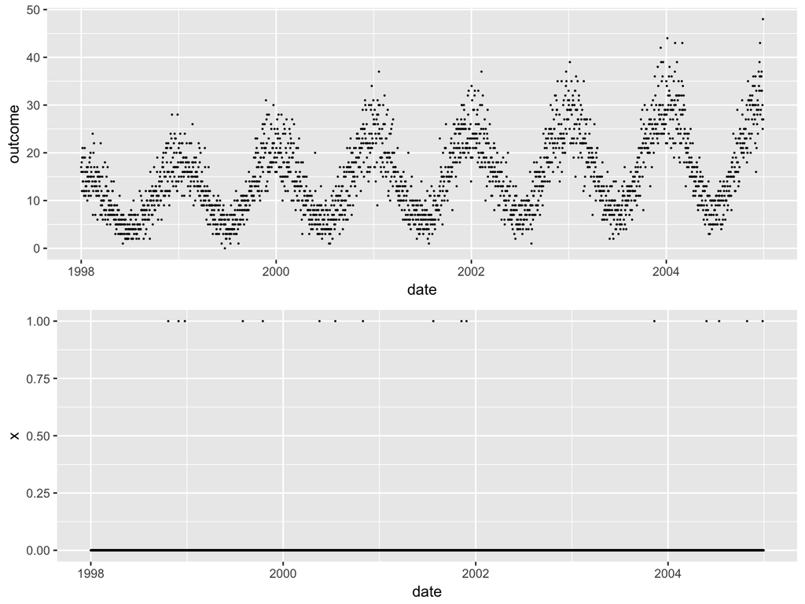

I use time series, time-stratified case-crossover, and matching analysis to analyze the simulated datasets. Then I can compare the results with the expected relative risk (1.02).

### Time series model

The following function fits a generalized linear model (GLM) with a spline function controlling for long-term and seasonal trend.

```r
mod_ts <- function(dat, df = 7, year_n = year_n){

  dat$time <- 1:nrow(dat)
  fit <- glm(outcome ~ x + ns(time, year_n*df), data = dat, family = poisson(link = "log"))

  coefs <- summary(fit)$coefficients
  coefs <- coefs["x", c("Estimate", "Std. Error")]
  log_rr <- coefs[1] + c(0, -1, 1) * 1.96 * coefs[2]
  rr <- exp(log_rr)

  return(rr)
}
```

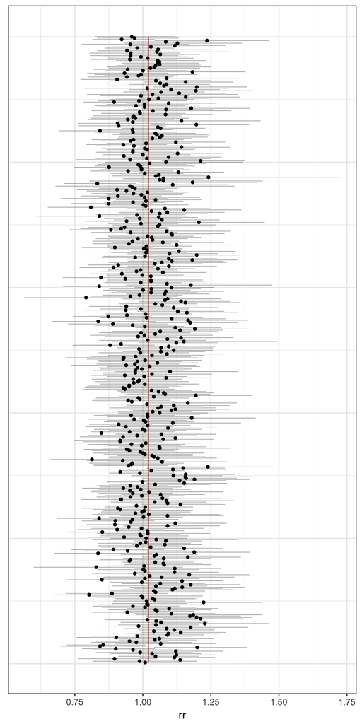

```r
ts_out <- map(sim_data, ~ mod_ts(dat = ., df = 7, year_n = year_n))
ts_out_df <- do.call(rbind.data.frame, ts_out)
colnames(ts_out_df) <- c("rr", "low", "high")
ts_out_df$n <- 1:nrow(ts_out_df)

ggplot(ts_out_df, aes(x = n, y = rr, ymin = low, ymax = high)) +
  geom_line(y = exp_rr, colour = "red") +
  geom_pointrange(size = 0.1) +
  theme_bw() +
  theme(axis.text.y = element_blank(), axis.ticks.y = element_blank(),
        axis.title.y = element_blank()) +
  coord_flip()
```

### Time-stratified case-crossover

The following function fit a GLM model based on time-stratified case-crossover design.

##### mod_cc_ymd: use a strata of “year”, “month”, and “day of week”.

##### mod_cc_wd: use a strata of “week of year” and “day of week”.

```r
mod_cc_ymd <- function(dat){

  library(lubridate)
  dat$year <- factor(year(dat$date))
  dat$month <- factor(month(dat$date))
  dat$dow <- factor(wday(dat$date, label = TRUE))
  dat$strata <- dat$year:dat$month:dat$dow

  fit <- glm(outcome ~ x + strata, data = dat, family = poisson(link = "log"))

  coefs <- summary(fit)$coefficients
  coefs <- coefs["x", c("Estimate", "Std. Error")]
  log_rr <- coefs[1] + c(0, -1, 1) * 1.96 * coefs[2]
  rr <- exp(log_rr)

  return(rr)
}

mod_cc_wd <- function(dat){

  library(lubridate)
  dat$week <- factor(week(dat$date))
  dat$dow <- factor(wday(dat$date, label = TRUE))
  dat$strata <- dat$week:dat$dow

  fit <- glm(outcome ~ x + strata, data = dat, family = poisson(link = "log"))

  coefs <- summary(fit)$coefficients
  coefs <- coefs["x", c("Estimate", "Std. Error")]
  log_rr <- coefs[1] + c(0, -1, 1) * 1.96 * coefs[2]
  rr <- exp(log_rr)

  return(rr)
}
```

##### Year:Month:DOW strata

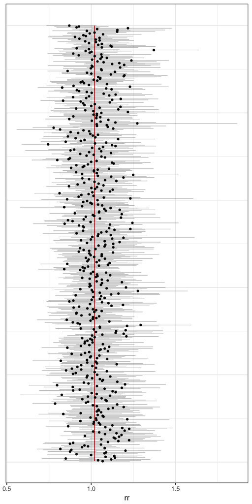

##### Week of year:DOW strata

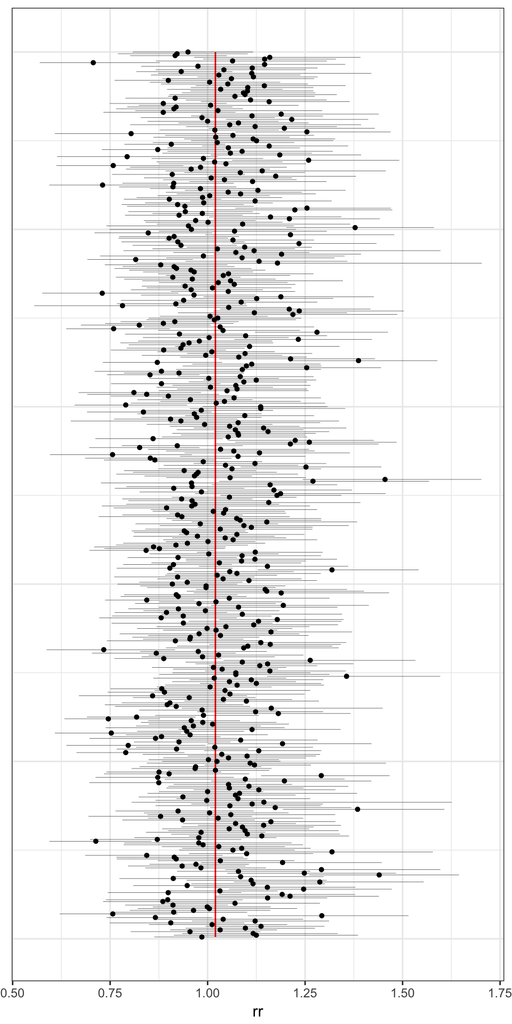

### Matching analysis

```r
mod_match <- function(dat){

   dat$doy <- yday(dat$date)
   dat$year <- year(dat$date)

   #cand_control <- c(which(dat$x == 1), which(dat$x == 1) - 1, which(dat$x == 1) + 1)
   #dat$cand_control <- TRUE
   #dat$cand_control[cand_control] <- FALSE

   two_week_911 <- seq(as.Date("2001-09-11"),  as.Date("2001-09-11") + 14, by = 1)
   dat$excu_911 <- ifelse(dat$date %in% two_week_911, FALSE, TRUE)

   case_dates <- subset(dat, x == 1)
   cand_control <- c(case_dates$date, case_dates$date - 1, case_dates$date + 1)
   dat$cand_control <- ifelse(dat$date %in% cand_control, FALSE, TRUE)

   control_dates <- subset(dat, x == 0)

for(i in 1:nrow(case_dates)){
    case <- subset(dat, date == case_dates[i, "date"])

    control_range <- case_dates[i, "doy"] + -3:3
    control_subset <- subset(control_dates,
                             control_dates$year != case_dates[i, "year"] &
                             control_dates$doy %in% control_range &
                             cand_control & excu_911)

    control <- sample_n(control_subset, 10)

    i_stratum <- rbind(case, control)

    if(i == 1){
      match_dat <- i_stratum
    }else{
      match_dat <- rbind(match_dat, i_stratum)
    }

}

  fit <- glm(outcome ~ x + year, data = match_dat, family = poisson(link = "log"))

  coefs <- summary(fit)$coefficients
  coefs <- coefs["x", c("Estimate", "Std. Error")]
  log_rr <- coefs[1] + c(0, -1, 1) * 1.96 * coefs[2]
  rr <- exp(log_rr)

  return(list("match_data" = match_dat, "rr" = rr))
}
```

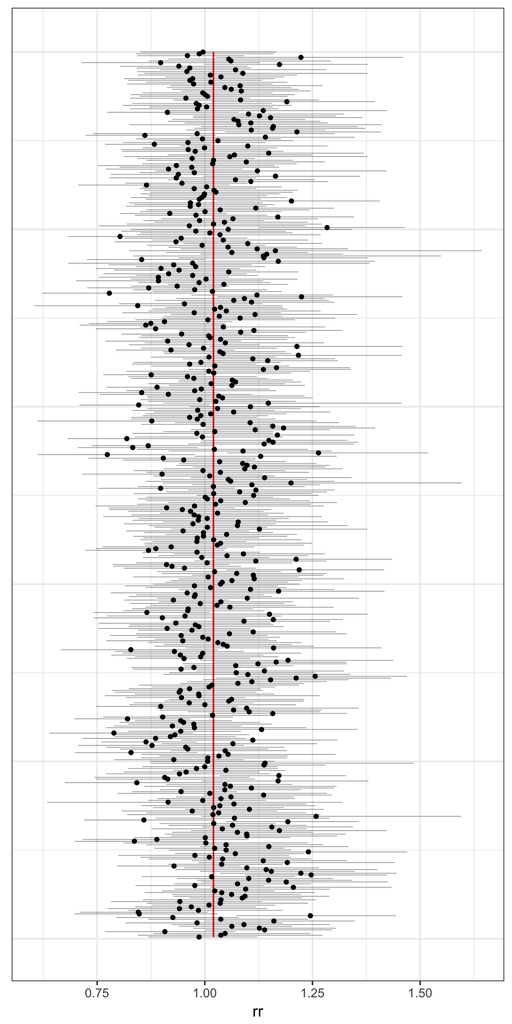

The following table shows the descriptive statistics of estimated relative risks (RR) using those four methods. The expected RR is 1.02.

|  | Min. | 1st Qu. | Median | Mean | 3rd Qu. | Max. |
| --- | --- | --- | --- | --- | --- | --- |
| Time series | 0.7911281 | 0.9638527 | 1.016790 | 1.024225 | 1.081530 | 1.241155 |
| Year:month:DOW | 0.7448534 | 0.9603813 | 1.027434 | 1.025397 | 1.085793 | 1.371307 |
| Week of year:DOW | 0.7067862 | 0.9383638 | 1.029470 | 1.028693 | 1.107941 | 1.455000 |
| Matching | 0.7735365 | 0.9664022 | 1.020345 | 1.025260 | 1.088974 | 1.283812 |